# Homework 5

Vaishnavi Maganti

2026-01-20

## Instructions

Answer the following questions and/or complete the exercises in RMarkdown. Please embed all of your code and push the final work to your repository. Your report should be organized, clean, and run free from errors. Remember, you must remove the `#` for any included code chunks to run. Any plots must have appropriate titles and aesthetics.

## Load the tidyverse

```r
library("tidyverse")
options(scipen=999) #turn off scientific notation
```

## Data

**Database of vertebrate home range sizes.** Reference: Tamburello N, Cote IM, Dulvy NK (2015) Energy and the scaling of animal space use. The American Naturalist 186(2):196-211. http://dx.doi.org/10.1086/682070.  
Data: http://datadryad.org/resource/doi:10.5061/dryad.q5j65/1

**1. Load the data into a new object called `homerange`.**

```r
getwd()
```

```
## [1] "/Users/magantiv/Desktop/clone_repository_github/BIS15L_W26_vmaganti/lab5.bak"
```

```r
homerange <- read_csv("/Users/magantiv/Desktop/clone_repository_github/BIS15L_W26_vmaganti/lab5.bak/data/Tamburelloetal_HomeRangeDatabase.csv")
```

**2. What is the structure of the `homerange` data? Does it have any NA’s? Do a quick exploratory analysis of your choice below.**

```r
glimpse(homerange)
```

```
## Rows: 569
## Columns: 24
## $ taxon                      <chr> "lake fishes", "river fishes", "river fishe…
## $ common.name                <chr> "american eel", "blacktail redhorse", "cent…
## $ class                      <chr> "actinopterygii", "actinopterygii", "actino…
## $ order                      <chr> "anguilliformes", "cypriniformes", "cyprini…
## $ family                     <chr> "anguillidae", "catostomidae", "cyprinidae"…
## $ genus                      <chr> "anguilla", "moxostoma", "campostoma", "cli…
## $ species                    <chr> "rostrata", "poecilura", "anomalum", "fundu…
## $ primarymethod              <chr> "telemetry", "mark-recapture", "mark-recapt…
## $ N                          <chr> "16", NA, "20", "26", "17", "5", "2", "2", …
## $ mean.mass.g                <dbl> 887.00, 562.00, 34.00, 4.00, 4.00, 3525.00,…
## $ log10.mass                 <dbl> 2.9479236, 2.7497363, 1.5314789, 0.6020600,…
## $ alternative.mass.reference <chr> NA, NA, NA, NA, NA, NA, NA, NA, NA, NA, NA,…
## $ mean.hra.m2                <dbl> 282750.00, 282.10, 116.11, 125.50, 87.10, 3…
## $ log10.hra                  <dbl> 5.4514026, 2.4504031, 2.0648696, 2.0986437,…
## $ hra.reference              <chr> "Minns, C. K. 1995. Allometry of home range…
## $ realm                      <chr> "aquatic", "aquatic", "aquatic", "aquatic",…
## $ thermoregulation           <chr> "ectotherm", "ectotherm", "ectotherm", "ect…
## $ locomotion                 <chr> "swimming", "swimming", "swimming", "swimmi…
## $ trophic.guild              <chr> "carnivore", "carnivore", "carnivore", "car…
## $ dimension                  <dbl> 3, 2, 2, 2, 2, 2, 2, 2, 2, 2, 2, 2, 2, 3, 3…
## $ preymass                   <dbl> NA, NA, NA, NA, NA, NA, 1.39, NA, NA, NA, N…
## $ log10.preymass             <dbl> NA, NA, NA, NA, NA, NA, 0.1430148, NA, NA, …
## $ PPMR                       <dbl> NA, NA, NA, NA, NA, NA, 530, NA, NA, NA, NA…
## $ prey.size.reference        <chr> NA, NA, NA, NA, NA, NA, "Brose U, et al. 20…
```

```r
names(homerange)
```

```
##  [1] "taxon"                      "common.name"
##  [3] "class"                      "order"
##  [5] "family"                     "genus"
##  [7] "species"                    "primarymethod"
##  [9] "N"                          "mean.mass.g"
## [11] "log10.mass"                 "alternative.mass.reference"
## [13] "mean.hra.m2"                "log10.hra"
## [15] "hra.reference"              "realm"
## [17] "thermoregulation"           "locomotion"
## [19] "trophic.guild"              "dimension"
## [21] "preymass"                   "log10.preymass"
## [23] "PPMR"                       "prey.size.reference"
```

**3. Which animal groups are represented in the data? Make a plot that shows the number in each class.**

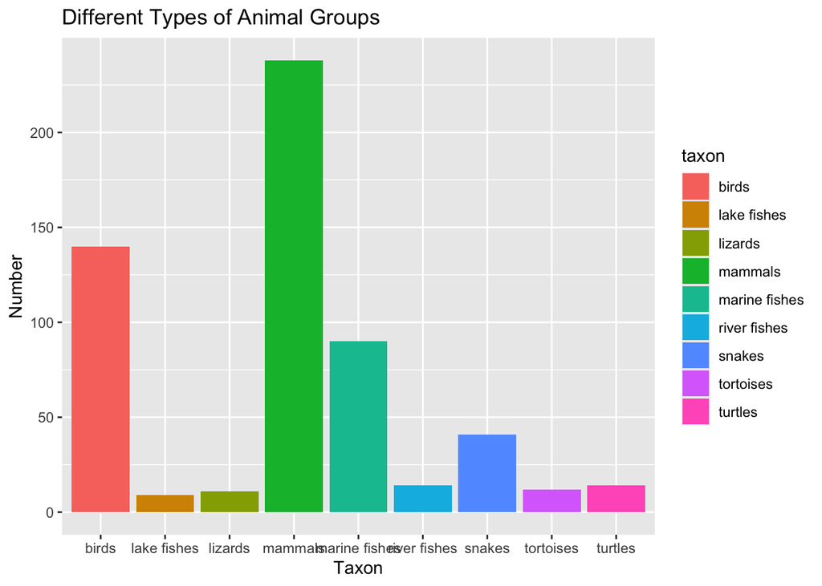

```r
ggplot(data=homerange,
       mapping=aes(x = taxon)) +
  geom_bar(aes(fill=taxon)) +
  labs(title= "Different Types of Animal Groups", x = "Taxon", y = "Number")
```

**4. Are there more carnivores or herbivores represented in the data? Make a plot that shows the number in each trophic guild.**

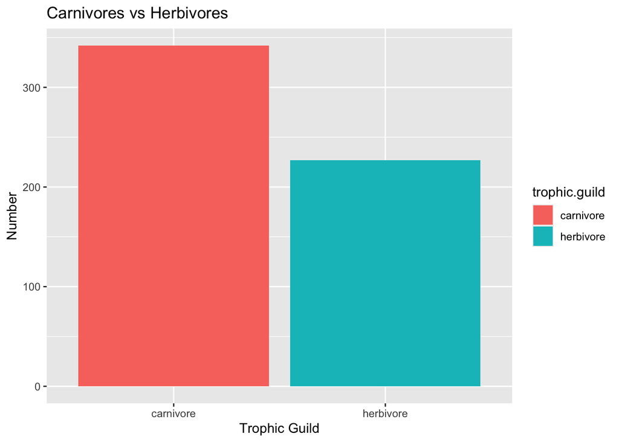

```r
homerange %>%
  filter(trophic.guild == "carnivore" | trophic.guild == "herbivore") %>%
ggplot(data = homerange,
       mapping=aes(x=trophic.guild)) +
  geom_bar(mapping=aes(fill=trophic.guild))+
  labs(title = "Carnivores vs Herbivores", x = "Trophic Guild", y = "Number" )
```

**5. Which herbivorous mammals have homeranges greater than 1,000,000 m²? Show only the common name, order, mean homerange size, and mean body mass. Arrange the data in descending order by homerange size and show only the top 10 species.**

```r
glimpse(homerange)
```

```
## Rows: 569
## Columns: 24
## $ taxon                      <chr> "lake fishes", "river fishes", "river fishe…
## $ common.name                <chr> "american eel", "blacktail redhorse", "cent…
## $ class                      <chr> "actinopterygii", "actinopterygii", "actino…
## $ order                      <chr> "anguilliformes", "cypriniformes", "cyprini…
## $ family                     <chr> "anguillidae", "catostomidae", "cyprinidae"…
## $ genus                      <chr> "anguilla", "moxostoma", "campostoma", "cli…
## $ species                    <chr> "rostrata", "poecilura", "anomalum", "fundu…
## $ primarymethod              <chr> "telemetry", "mark-recapture", "mark-recapt…
## $ N                          <chr> "16", NA, "20", "26", "17", "5", "2", "2", …
## $ mean.mass.g                <dbl> 887.00, 562.00, 34.00, 4.00, 4.00, 3525.00,…
## $ log10.mass                 <dbl> 2.9479236, 2.7497363, 1.5314789, 0.6020600,…
## $ alternative.mass.reference <chr> NA, NA, NA, NA, NA, NA, NA, NA, NA, NA, NA,…
## $ mean.hra.m2                <dbl> 282750.00, 282.10, 116.11, 125.50, 87.10, 3…
## $ log10.hra                  <dbl> 5.4514026, 2.4504031, 2.0648696, 2.0986437,…
## $ hra.reference              <chr> "Minns, C. K. 1995. Allometry of home range…
## $ realm                      <chr> "aquatic", "aquatic", "aquatic", "aquatic",…
## $ thermoregulation           <chr> "ectotherm", "ectotherm", "ectotherm", "ect…
## $ locomotion                 <chr> "swimming", "swimming", "swimming", "swimmi…
## $ trophic.guild              <chr> "carnivore", "carnivore", "carnivore", "car…
## $ dimension                  <dbl> 3, 2, 2, 2, 2, 2, 2, 2, 2, 2, 2, 2, 2, 3, 3…
## $ preymass                   <dbl> NA, NA, NA, NA, NA, NA, 1.39, NA, NA, NA, N…
## $ log10.preymass             <dbl> NA, NA, NA, NA, NA, NA, 0.1430148, NA, NA, …
## $ PPMR                       <dbl> NA, NA, NA, NA, NA, NA, 530, NA, NA, NA, NA…
## $ prey.size.reference        <chr> NA, NA, NA, NA, NA, NA, "Brose U, et al. 20…
```

```r
names(homerange)
```

```
##  [1] "taxon"                      "common.name"
##  [3] "class"                      "order"
##  [5] "family"                     "genus"
##  [7] "species"                    "primarymethod"
##  [9] "N"                          "mean.mass.g"
## [11] "log10.mass"                 "alternative.mass.reference"
## [13] "mean.hra.m2"                "log10.hra"
## [15] "hra.reference"              "realm"
## [17] "thermoregulation"           "locomotion"
## [19] "trophic.guild"              "dimension"
## [21] "preymass"                   "log10.preymass"
## [23] "PPMR"                       "prey.size.reference"
```

```r
homerange %>%
  filter(mean.hra.m2> 1000000)  %>%
  select(common.name, order, mean.hra.m2, mean.mass.g)  %>%
  arrange(desc(mean.hra.m2))
```

```
## # A tibble: 144 × 4
##    common.name           order         mean.hra.m2 mean.mass.g
##    <chr>                 <chr>               <dbl>       <dbl>
##  1 reindeer              artiodactyla  3550830977      102059.
##  2 African bush elephant proboscidea   1753759352     4000000.
##  3 greater kudu          artiodactyla  1070039969      197315.
##  4 cheetah               carnivora      815060788.      50000
##  5 leopard               carnivora      504940261.      48375.
##  6 caracal               carnivora      376634414       13000.
##  7 wolverine             carnivora      361917847.      21546.
##  8 cougar                carnivora      312003884.      89999.
##  9 American bison        artiodactyla   265778594.     629999.
## 10 caracara              falconiformes  241000000        1125
## # ℹ 134 more rows
```

**6. Which two species have the largest and smallest homerange sizes?**

```r
homerange %>%
  select(species, preymass) %>%
 slice_max(preymass, n=2)
```

```
## # A tibble: 2 × 2
##   species preymass
##   <chr>      <dbl>
## 1 tigris   130233.
## 2 uncia     57547.
```

```r
homerange %>%
  select(species, preymass) %>%
 slice_min(preymass, n=2)
```

```
## # A tibble: 2 × 2
##   species    preymass
##   <chr>         <dbl>
## 1 inermis        0.67
## 2 pollachius     1.39
```

**7. Which carnivorous mammals have the largest homeranges?**

```r
homerange %>%
  filter(trophic.guild == "carnivore") %>%
arrange(desc(trophic.guild))
```

```
## # A tibble: 342 × 24
##    taxon        common.name class order family genus species primarymethod N
##    <chr>        <chr>       <chr> <chr> <chr>  <chr> <chr>   <chr>         <chr>
##  1 lake fishes  american e… acti… angu… angui… angu… rostra… telemetry     16
##  2 river fishes blacktail … acti… cypr… catos… moxo… poecil… mark-recaptu… <NA>
##  3 river fishes central st… acti… cypr… cypri… camp… anomal… mark-recaptu… 20
##  4 river fishes rosyside d… acti… cypr… cypri… clin… fundul… mark-recaptu… 26
##  5 river fishes longnose d… acti… cypr… cypri… rhin… catara… mark-recaptu… 17
##  6 river fishes muskellunge acti… esoc… esoci… esox  masqui… telemetry     5
##  7 marine fish… pollack     acti… gadi… gadid… poll… pollac… telemetry     2
##  8 marine fish… saithe      acti… gadi… gadid… poll… virens  telemetry     2
##  9 marine fish… giant trev… acti… perc… caran… cara… ignobi… telemetry     4
## 10 lake fishes  rock bass   acti… perc… centr… ambl… rupest… mark-recaptu… 16
## # ℹ 332 more rows
## # ℹ 15 more variables: mean.mass.g <dbl>, log10.mass <dbl>,
## #   alternative.mass.reference <chr>, mean.hra.m2 <dbl>, log10.hra <dbl>,
## #   hra.reference <chr>, realm <chr>, thermoregulation <chr>, locomotion <chr>,
## #   trophic.guild <chr>, dimension <dbl>, preymass <dbl>, log10.preymass <dbl>,
## #   PPMR <dbl>, prey.size.reference <chr>
```

**8. Is there a relationship between body mass and homerange size? Make a scatterplot to show this relationship. Be sure to include appropriate labels and a title.**

```r
names(homerange)
```

```
##  [1] "taxon"                      "common.name"
##  [3] "class"                      "order"
##  [5] "family"                     "genus"
##  [7] "species"                    "primarymethod"
##  [9] "N"                          "mean.mass.g"
## [11] "log10.mass"                 "alternative.mass.reference"
## [13] "mean.hra.m2"                "log10.hra"
## [15] "hra.reference"              "realm"
## [17] "thermoregulation"           "locomotion"
## [19] "trophic.guild"              "dimension"
## [21] "preymass"                   "log10.preymass"
## [23] "PPMR"                       "prey.size.reference"
```

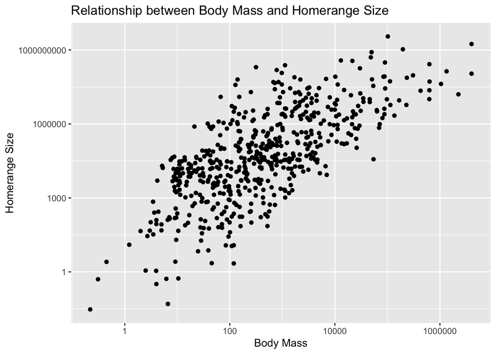

```r
ggplot(data = homerange,
       mapping=aes(x=mean.mass.g, y=mean.hra.m2)) +
  geom_point() +
labs(title="Relationship between Body Mass and Homerange Size", x= "Body Mass", y= "Homerange Size") +
scale_y_log10() +
scale_x_log10()
```

**9. Use filter to extract the data for only birds and mammals. Then make a plot that compares the homerange sizes of these two groups. Be sure to include appropriate labels and a title.**

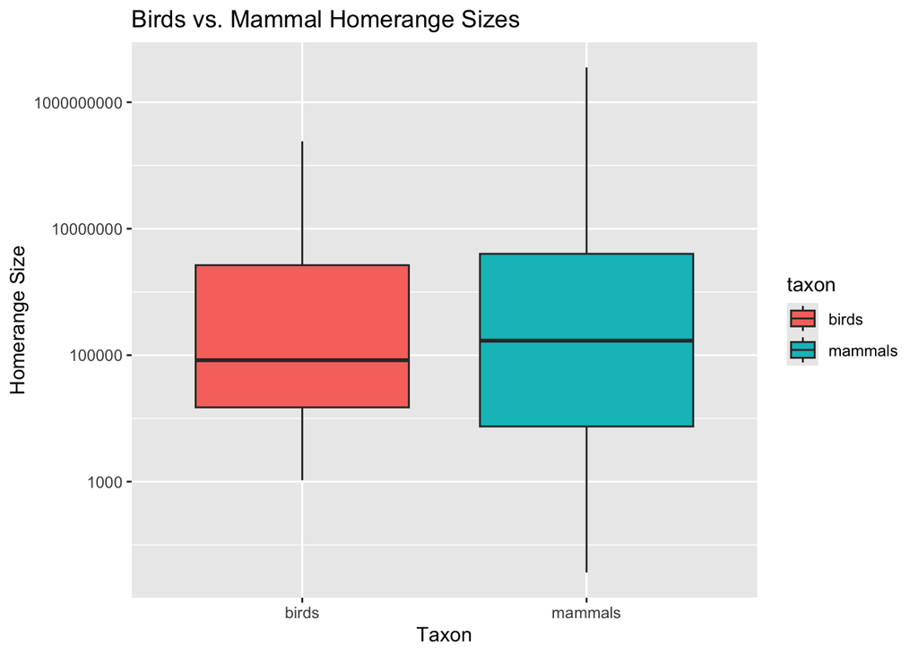

```r
homerange %>%
  select(taxon, mean.hra.m2) %>%
filter(taxon %in% c("birds", "mammals")) %>%
  ggplot(mapping=aes(x=taxon, y = mean.hra.m2)) +
  geom_boxplot(mapping=aes(fill=taxon)) +
  scale_y_log10() +
  labs(title= "Birds vs. Mammal Homerange Sizes", x = "Taxon", y="Homerange Size")
```

**10. Do one additional exploratory analysis of your choice. Before writing the code, write the question you are trying to answer. The question should be biologically meaningful and appropriate for the data. It must include at least one `filter()`, `select()`, and `arrange()`.**

Which species that walk or fly have the largest home ranges?

```r
homerange %>%
  filter(locomotion=="walking" | locomotion=="flying") %>%
  select(species, locomotion, mean.hra.m2) %>%
  arrange(desc(mean.hra.m2))
```

```
## # A tibble: 416 × 3
##    species      locomotion mean.hra.m2
##    <chr>        <chr>            <dbl>
##  1 tarandus     walking    3550830977
##  2 africana     walking    1753759352
##  3 strepsiceros walking    1070039969
##  4 jubatus      walking     815060788.
##  5 pardus       walking     504940261.
##  6 caracal      walking     376634414
##  7 gulo         walking     361917847.
##  8 concolor     walking     312003884.
##  9 bison        walking     265778594.
## 10 cheriway     walking     241000000
## # ℹ 406 more rows
```

## Knit and Upload

Please knit your work as an .html file and upload to Canvas. Homework is due before the start of the next lab. No late work is accepted. Make sure to use the formatting conventions of RMarkdown to make your report neat and clean!